© Guven

# Feature Selection and Extraction

## Introduction

```
"If you have extracted the wrong features, no classifier will work; if you have extracted the right features, any classifier will work.", King-Sun Fu
```

Features are independent variables that measure a property or characteristic of a particular problem. Selecting informative, discriminative, and independent features is the most important process of any learning model.

## Feature Selection

The process of selecting a subset of strong features as independent variables of the learning model is called **feature selection**.

- Simplification of models to make them explainable
- Requires less computation in training
- Avoid the curse of dimensionality, especially an issue for probabilistic models
- Improve data compatibility with a learning model class, such as ONNX models
- Encode inherent symmetries present in the input space, such as in reinforcement learning

Generally a feature selection is possible because the features we collected are dependent to each other.

## Feature Extraction

Feature extraction is a process of dimensionality reduction by which an initial set of raw data is reduced to more manageable groups for processing. A characteristic of these large data sets is a large number of variables such as in text, audio, or image processing. Feature extraction is the process to select and combine variables into feature vectors, effectively reducing the amount of data, while still accurately, completely describing the original dataset.

## Latent Space

A **latent feature space** or **embedding space** is an embedding of a set of data points within a manifold in which items resembling each other are positioned closer to one another. The coordinates, or positions within the latent space are a new representation of those objects, effectively extracted (new) features.

Manifold learning is the process of finding a **manifold** which can generalize linear frameworks like PCA to be sensitive to non-linear structures in data.

Geometric surfaces can be described by manifolds. On a manifold, the data points are reachable by a linear course even though the manifold can be of higher dimensions. Such as an ant walking on a cube in a straight direction. From the point of view of the ant, everywhere it walks should look like a flat plane.

This process not only reduces the original number of dimensions but also places similar data points in higher dimensions to be close to each other in lower dimensions. Something like data compression but also clustering together. This kind of feature extraction helps a classifier.

## Text Bag-of-Words

Text Analysis is a major application field for machine learning algorithms. However, the raw data, a sequence of symbols cannot be fed directly to the algorithms themselves as most of them expect numerical feature vectors with a fixed size rather than the raw text documents with variable length.

In Natural Language Processing (NLP) field, text analysis is helped by methods specific to linguistics or language. In NLP, the feature is the **token** delimited by white space determined by the language. Required steps for feature extraction as in the following,

- tokenizing strings, and assigning an integer id for each possible token
- counting the occurrences of tokens in each document
  - note that a document can be a phrase, sentence, paragraph, section, chapter, or even a book, etc.
- normalizing and weighting with diminishing importance tokens that occur in the majority of samples/documents

Let's see an example based on **TF-IDF** feature extraction (i.e. Term Frequency - Inverse Document Frequency).

The measure of a feature (token/term) in a document is simply proportional to the term's frequency. However, this metric has to be *normalized* because the term frequency alone will tend to incorrectly emphasize documents which happen to use common and frequently used words (such as 'the', if stop-word filtered then 'news' in a news corpus), without giving enough weight to the more meaningful terms (such as 'alien' or 'inflation'). This normalization can be based on the number of the documents by counting how many documents have *that* term.

$\texttt{tfidf}(t,d,D) = \texttt{tf}(t,d) \cdot \texttt{idf}(t,D)$, where

$\texttt{tf}(t,d) = f_{t,d}$, which is the raw count of term $t$ in document $d$

$\texttt{idf}(t,D) = \log \frac {N}{ |\{ d \in D : t \in d \}| }$

$N=|D|$, total number of documents $d$ in the corpus of $D$

`sklearn` library has the method `TfidfVectorizer` to generate the features for a given document.

## Audio Feature Extraction

A variety of acoustic features have also been explored. Such as acoustic profiles and the acoustic features of fundamental frequency/pitch (F0), energy, speech rate, and spectral information in voiced and unvoiced portions are utilized. Speech synthesis for archetypal emotions using acoustic features of (1) pitch-related features; (2) formant frequencies; (3) timing features; (4) voice-quality parameters; and (5) articulation parameters. In several studies it is suggested the qualitative acoustic features of (1) voice level; (2) voice pitch; (3) phrase, word, phoneme and feature boundaries; (4) temporal structure for the six archetypal emotions (happiness, sadness, surprise, anger, disgust and fear). In addition, researchers studied thirty-two different acoustic features (related to F0, energy, duration, and tune) for the classification of five emotion states.

In an earlier module we used spectrogram features to represent cats and dogs sounds.

## Image Feature Extraction

A Convolutional Neural network CNN is a multiple-layer neural network that consists of convolutional layers, pooling layers, and fully connected layers as hidden layers. In a convolution layer, a filter is slid across the data, and feature maps are extracted through element-wise multiplication. In general, a convolution layer has multiple filters, where one filter creates one feature map. The role of this layer is feature extraction.

The convolution is performed by multiplying the filter pixel wise with the portion of the image, and summing the result. The output is more positive when the portion of the image closely matches the filter and more negative when the portion of the image is the inverse of the filter. If we move the filter across the entire image, from left to right and top to bottom, recording the convolutional output as we go, we obtain a new array that picks out a particular feature of the input, depending on the values in the filter.

There are several algorithms to detect features such as shaped, edges, or motion in a digital image or video.

## Autoencoders

The purpose of autoencoders is unsupervised learning of efficient data encoding. Feature extraction can identify key features in the data for coding by learning from the coding of the original data set to derive new ones. In a way autoencoders can discover Lego pieces of the images, or subimages, to be used to construct larger images by linear combinations.

Autoencoders are a type of neural network which generates an "n-layer" coding of the given input and attempts to reconstruct the input using the *code* generated. This NN architecture is composed of the encoder structure, the decoder structure, and the latent space, also known as the "bottleneck". To learn the data representations of the input, the network is trained using given dataset, no labels needed. These compressed, data representations go through a decoding process wherein which the input is reconstructed. An autoencoder is a regression task that models an identity function.

### Variational Autoencoders

If an embedding (or a latent vector) falls in the middle of two clusters, then that particular data point might be represented by an incorrect feature vector. Variational autoencoders (VAE) help resolve this problem by generating feature vectors that have a 0-mean and 1-standard-deviation.

## Sparse Coding

Given a dataset, sparse coding involves learning a more efficient basis from over-complete bases. The aim of sparse coding is to find a set of basis vectors $\phi_i$ such that an input vector $x$ can be represented as a linear combination of these basis vectors, $x=\sum\limits_{i=1}^k a_i \phi_i$, such that only a few non-zero components $a_i$ are allowed, hence the **sparsity**.

The sparse coding cost function,

$\texttt{minimize}_{a_i^{(j)},\phi_i}\sum\limits_{j=1}^m \| x^{(j)} − \sum\limits_{i=1}^k a_i^{(j)} \phi_i \|^2 + \lambda \sum\limits_{i=1}^k S(a_i^{(j)})$, where $x \in \mathbb{R}^n$

The $S(.)$ is a sparsity cost function which penalizes $a_i$ for being non-zero. The first term of the sparse coding objective as a reconstruction term which tries to force the algorithm to provide a good representation of $x$ and the second term as a sparsity penalty which forces the representation of $x$ to be sparse. The constant $\lambda$ is a scaling constant to determine the relative importance of these two components.

Techniques such as Principal Component Analysis (PCA) help learn a complete set of basis vectors efficiently, albeit lossy, without any constraint on $a_i$.

```python
%matplotlib inline
import matplotlib.pyplot as plt
plt.rcParams['figure.dpi'] = 72
```

```python
from nltk.corpus import reuters
from string import punctuation
from nltk.corpus import stopwords
from nltk import word_tokenize
import re  # we will remove some contractions with regular expression
from sklearn.feature_extraction.text import TfidfVectorizer

# Combination of stop words and punctuations
Stop_words = stopwords.words('english') + list(punctuation)

# Drop digits for this example
def tokenize(text):
    terms = word_tokenize(text)
    # all lower case
    terms = [w.lower() for w in terms]
    # filter stop words
    terms = [w for w in terms if w not in Stop_words and not w.isdigit()]
    # remove contractions, the best way might be having a list
    terms = [w for w in terms if not re.search(r'^\W\w+$', w)]
    return terms

N = len(reuters.fileids())

print(f'Reuters documents count N= {N}')
```

```
Reuters documents count N= 10788
```

```python
# Feature extractor
tfidf1 = TfidfVectorizer().fit([reuters.raw(fid) for fid in reuters.fileids()])

print(f'Vocabulary size {len(tfidf1.vocabulary_)}')
```

```
Vocabulary size 30916
```

```python
# Use our tokenizer
tfidf2 = TfidfVectorizer(tokenizer=tokenize, token_pattern=None).fit([reuters.raw(fid) for fid in reuters.fileids()])

print(f'Vocabulary size {len(tfidf2.vocabulary_)}')
```

```
Vocabulary size 51632
```

```python
# Transform a document into TfIdf numerical values, X can also be used for an ML learning model
X = tfidf1.transform([reuters.raw('test/14829')])

test_words = ['energy', 'power', 'japanese', 'downtrend', 'structural', 'year', 'also']
for t in test_words:
    print(f'{X[0,tfidf1.vocabulary_[t]]:.5f} {t}')
```

```
0.42947 energy
0.12496 power
0.10370 japanese
0.10072 downtrend
0.08164 structural
0.04959 year
0.03317 also
```

```python
# Transform a document into TfIdf numerical values, X can also be used for an ML learning model
X = tfidf2.transform([reuters.raw('test/14829')])

test_words = ['energy', 'power', 'japanese', 'downtrend', 'structural', 'year', 'also']
for t in test_words:
    print(f'{X[0,tfidf2.vocabulary_[t]]:.5f} {t}')
```

```
0.47503 energy
0.13810 power
0.11453 japanese
0.11118 downtrend
0.09011 structural
0.05627 year
0.03661 also
```

```python
# original document
print(reuters.raw('test/14829'))
```

```
JAPAN TO REVISE LONG-TERM ENERGY DEMAND DOWNWARDS
  The Ministry of International Trade and
  Industry (MITI) will revise its long-term energy supply/demand
  outlook by August to meet a forecast downtrend in Japanese
  energy demand, ministry officials said.
      MITI is expected to lower the projection for primary energy
  supplies in the year 2000 to 550 mln kilolitres (kl) from 600
  mln, they said.
      The decision follows the emergence of structural changes in
  Japanese industry following the rise in the value of the yen
  and a decline in domestic electric power demand.
      MITI is planning to work out a revised energy supply/demand
  outlook through deliberations of committee meetings of the
  Agency of Natural Resources and Energy, the officials said.
      They said MITI will also review the breakdown of energy
  supply sources, including oil, nuclear, coal and natural gas.
      Nuclear energy provided the bulk of Japan's electric power
  in the fiscal year ended March 31, supplying an estimated 27
  pct on a kilowatt/hour basis, followed by oil (23 pct) and
  liquefied natural gas (21 pct), they noted.
```

## Autoencoder Example

Let's implement a vanilla autoencoder working on the MNIST dataset. `Z_DIM` is the latent space. The decoded images need to be detached (`detach()`), to be stored in the list for visualization. The latent space dimension can be as low as 1 dimension, i.e. single perceptron. Note that every image is stored in the debug list so use the number of epochs to reach the last trained model and reconstructed image.

```python
import sys
import torch
import torchvision
from torchvision import datasets, transforms

# Set the GPU to device 0
gpu = torch.device('cuda:0')

print(f'PyTorch version= {torch.__version__}')
print(f'torchvision version= {torchvision.__version__}')
print(f'CUDA available= {torch.cuda.is_available()}')

dataset = datasets.MNIST(root = "./data",
                         train = True,
                         download = True,
                         transform = transforms.ToTensor())
BATCH_SIZE = 256
loader = torch.utils.data.DataLoader(dataset=dataset, batch_size=BATCH_SIZE, shuffle=True)
```

```
PyTorch version= 2.0.1
torchvision version= 0.15.2
CUDA available= True
```

```python
X_DIM= 28  # size of the images

class Autoencoder(torch.nn.Module):
    def __init__(self, z_dim):
        super().__init__()
        self.z_dim= z_dim

        self.encoder = torch.nn.Sequential(
            torch.nn.Linear(X_DIM*X_DIM, 128),
            torch.nn.ReLU(inplace=True),
            torch.nn.Linear(128, 64),
            torch.nn.ReLU(inplace=True),
            torch.nn.Linear(64, self.z_dim)
        )

        self.decoder = torch.nn.Sequential(
            torch.nn.Linear(self.z_dim, 64),
            torch.nn.ReLU(inplace=True),
            torch.nn.Linear(64, 128),
            torch.nn.ReLU(inplace=True),
            torch.nn.Linear(128, X_DIM*X_DIM),
            torch.nn.Sigmoid()  # why not Tanh?
        )

    def forward(self, _X):
        encoded = self.encoder(_X)
        decoded = self.decoder(encoded)
        return decoded
```

```python
Z_DIM = 10  # latent space dimension

ae_model = Autoencoder(Z_DIM).to(gpu)
loss_func  = torch.nn.MSELoss()
optim = torch.optim.Adam(ae_model.parameters(), lr=0.001, weight_decay=1e-5)
```

```python
%%time

EPOCHS = 10
debug, loss_train = [], []
for e in range(EPOCHS):
    loss = None
    for (img, _) in loader:
        img = img.reshape(-1, X_DIM*X_DIM).to(gpu)
        reconstructed = ae_model(img)
        loss = loss_func (reconstructed, img)

        optim.zero_grad()
        loss.backward()
        optim.step()

        loss_train += [loss.item()]
        debug.append((e, img.cpu(), reconstructed.detach().cpu()))
    sys.stderr.write(f"\r{e+1:02d}/{EPOCHS:02d} | Loss: {loss:<6.4f}")
    sys.stderr.flush()
```

```
10/10 | Loss: 0.0210
```

```
CPU times: total: 1min 39s
Wall time: 1min 23s
```

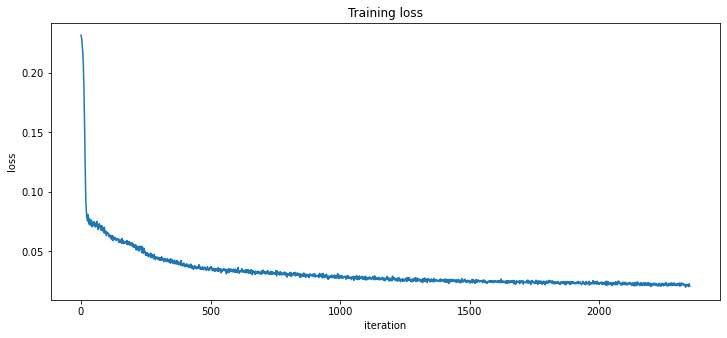

```python
# training progress
plt.figure(figsize=(12,5), dpi=72)
plt.gca().set(xlabel='iteration', ylabel='loss', title='Training loss')
plt.plot(loss_train)
plt.show()
```

```python
def plot(_ix):
    _, ax = plt.subplots(1, 2, figsize=(12,4), dpi=72)
    ax = ax.flatten()
    img_, reconstructed_ = debug[_ix][1], debug[_ix][2]
    img_ = img_.reshape(-1, X_DIM, X_DIM)
    ax[0].imshow(img_[0])
    reconstructed_ = reconstructed_.reshape(-1, X_DIM, X_DIM)
    ax[1].imshow(reconstructed_[0])
    plt.show()

# check some reconstructions
print(f'the number of stored debug images= {len(debug)}')
```

```
the number of stored debug images= 2350
```

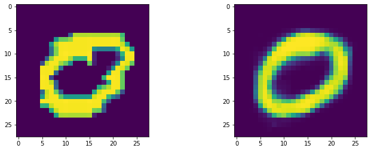

```python
plot(2340)
```

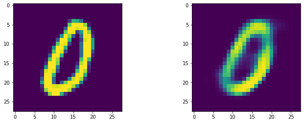

```python
plot(2349)
```

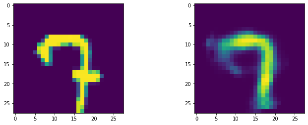

```python
plot(2345)
```

## References

1. Capellman, Jarred. Hands-On Machine Learning with ML. NET: Getting started with Microsoft ML. NET to implement popular machine learning algorithms in C. Packt Publishing Ltd, 2020.
2. Guven, Erhan, and Peter Bock. "Speech emotion recognition using a backward context." 2010 IEEE 39th Applied Imagery Pattern Recognition Workshop (AIPR). IEEE, 2010.
3. Alom, Md Zahangir, et al. "The history began from alexnet: A comprehensive survey on deep learning approaches." arXiv preprint arXiv:1803.01164 (2018).

## Exercises

**Exercise 1.** What is the relation between Tf-Idf measure of a token to the conditional probability of that token given a document class?

**Exercise 2.** Use PSO to optimize sparse coding for a selected dataset.

**Exercise 3.** Try reducing the size of the latent space dimension. Did it work?

**Exercise 4.** Convert linear layers to CNN layers in the Autoencoder.

```python
%%html
<style>
    table {margin-left: 0 !important;}
</style>
<!-- Display markdown tables left oriented in this notebook. -->
```